# Design of Magnetic Cores Lm and Lr

[figure not shown]

- Inputs and claculated parameters
- Transformer design
  - Core ELP 64/10/50 with I 64/5/50
  - Other cores
  - Choice of the transformer core ELP 64 vs ELP 102

Lr design

- 4 turns, one turns by layer
- More than 4 turns

Bill of Materials (BOM) of this transformer and Lr (Cores)

References

## Inputs and claculated parameters

```
V_In_min 360.0 V_In_max 400.0 Vo_nom 48.0 Power   1200.0
V_In_nom 380.0   Vo_min  42.0 Vo_max 54.0 f_nom 100000.0


  Lnc   3.000   Lm_uH     65.392     Ioe_rms  7.636 Re_110    22.637
  Qec   0.550 fsw_min  60170.000     Ios_rms 30.545     Cr       0.0
Cr_nF 116.209 fsw_max 156220.000      Ir_rms 10.354     Lr  0.000022
    n   4.000  Im_rms      6.992 L_second_uH  4.087     Lm  0.000065
Lr_uH  21.797      Io     25.000      Re_nom 24.901
```

## Transformer design

|  | Transormer parameters |
| --- | --- |
| n | 4.000 |
| Lm_uH | 65.392 |
| fsw_min | 60170.000 |
| fsw_max | 156220.000 |
| Ir_rms | 10.354 |
| Im_rms | 6.992 |
| Ioe_rms | 7.636 |
| Ios_rms | 30.545 |
| L_second_uH | 4.087 |
| Al_uH | 4.087 |

**Bpeak formula**

$$ B_{peak} = \frac{L_m \cdot Im_{peak}}{N_p \cdot A_e}= \frac{L_m \cdot \sqrt{2} \cdot Im_{rms}}{N_p \cdot A_e} $$

Where

- `A_e` = effective core area (in m²)
- `N_p` = primary turns

The `Al` value:

$ \begin{aligned} \mathrm{Al}_{nH} &= 1 \times 10 ^ {3} \cdot \frac{ \mathrm{Lm}_{uH} }{ \left( n \right) ^{ 2 } } \\&= 1 \times 10 ^ {3} \cdot \frac{ 65.392 }{ \left( 4.000 \right) ^{ 2 } } \\&= 4087.000 \; \;\textrm{(nH/turn squared)}\\[10pt] \end{aligned} $

We can reduce $A_L$ by adding an air gap, below the formula of air gap length

$$ A_{L}' = \frac{A_L}{1 + \mu_r \,\frac{L_g}{L_e}} $$

$$ l_g = \frac{L_e}{\mu_r} \left( \frac{A_L}{A_L'} - 1 \right) $$

Where

- $ A_{L}' $ : the corrected inductance factor (in nH or µH), after introducing the air gap
- $ A_L $ : the initial inductance factor provided by the core manufacturer (in nH or µH)
- $ l_g $ : the air gap length (in mm)
- $ L_e $ : the effective magnetic path length of the core (in mm)

### Core ELP 64/10/50 with I 64/5/50

#### Inputs data

μ_r: relative permeability (material property) μ_e: effective permeability (assembly/shape property)

$ \begin{aligned} \mathrm{core} &= \mathrm{} \; \;\textrm{(ELP 64/10/50 with I 64/5/50)} \\[10pt] \mathrm{Al}_{nH} &= 14000 \; \;\textrm{(nH)} \\[10pt] A_{e} &= 519 \; \;\textrm{(mm2)} \\[10pt] A_{e_{min}} &= 518 \; \;\textrm{(mm2)} \\[10pt] l_{e} &= 69.700 \; \;\textrm{(mm)} \end{aligned} $

$ \begin{aligned} \mu_{r} &= 1450 \; \;\textrm{(N87)} \\[10pt] B_{sat} &= 300 \; \;\textrm{(mT @ 250A/m 10kHz 100°C)} \\[10pt] \mathrm{K1} &= 835 \; \;\textrm{(@ 25°C, 0.10 mm < s < 2.00 mm)} \\[10pt] \mathrm{K2} &= -0.790 \; \;\textrm{(@ 25°C, 0.10 mm < s < 2.00 mm)} \\[10pt] \mu_{0} &= 4 \cdot \pi \cdot 1 \times 10 ^ {-7} = 4 \cdot 3.142 \cdot 1 \times 10 ^ {-7} &= 0.000 \; \;\textrm{(H m−1)} \end{aligned} $

#### The air gap

$ \begin{aligned} \mathrm{Lm}_{nH} &= \mathrm{Lm}_{uH} \cdot 1 \times 10 ^ {3} = 65.392 \cdot 1 \times 10 ^ {3} &= 65392.000 \; \;\textrm{(nH)} \\[10pt] \mathrm{Al}_{nH} &= 14000 \; \;\textrm{(nH)} \\[10pt] \mathrm{Al}_{Target} &= \frac{ \mathrm{Lm}_{nH} }{ \left( n \right) ^{ 2 } } = \frac{ 65392.000 }{ \left( 4.000 \right) ^{ 2 } } &= 4087.000 \; \;\textrm{(nH)} \\[10pt] \mu_{eTarget} &= \mu_{r} \cdot \frac{ \mathrm{Al}_{Target} }{ \mathrm{Al}_{nH} } = 1450 \cdot \frac{ 4087.000 }{ 14000 } &= 423.296 \end{aligned} $

**Simified formula of air gap**

See the formula above

$ \begin{aligned} l_{g} &= 1 \times 10 ^ {3} \cdot \left( \frac{ \mu_{0} \cdot \left( n \right) ^{ 2 } \cdot A_{e} \cdot 1 \times 10 ^ {-6} }{ \mathrm{Lm} } - l_{e} \cdot \frac{ 1 \times 10 ^ {-3} }{ \mu_{r} } \right) \\&= 1 \times 10 ^ {3} \cdot \left( \frac{ 0.000 \cdot \left( 4.000 \right) ^{ 2 } \cdot 519 \cdot 1 \times 10 ^ {-6} }{ 0.000 } - 69.700 \cdot \frac{ 1 \times 10 ^ {-3} }{ 1450 } \right) \\&= 0.112 \; \;\textrm{(mm)}\\[10pt] \end{aligned} $

**TDK formula of air gap using K1 and K2**

[figure not shown]

**Figure 1:** The empirical air-gap formula using the coefficients K1 and K2 from the TDK datasheet

See page 6 [1].

$ \begin{aligned} s_{mm} &= \left( \frac{ \mathrm{Al}_{Target} }{ \mathrm{K1} } \right) ^{ \left( \frac{ 1 }{ \mathrm{K2} } \right) } \\&= \left( \frac{ 4087.000 }{ 835 } \right) ^{ \left( \frac{ 1 }{ -0.790 } \right) } \\&= 0.134 \; \;\textrm{(mm airgap)}\\[10pt] \end{aligned} $

**TDK air gap curve**

[figure not shown]

See page 2 [2].

$ \begin{aligned} l_{g_{curve}} &= 0.140 \; \;\textrm{(mm)} \end{aligned} $

**Air gap using the tree methods**

$ \begin{aligned} s_{mm} &= 0.134 \; \;\textrm{(mm using TDK formula K1, K2)} \\[10pt] l_{g} &= 0.112 \; \;\textrm{(mm using the simple formula)} \\[10pt] l_{g_{curve}} &= 0.140 \; \;\textrm{(mm using TDK graph)} \end{aligned} $

The three results are close to each other; we will prefer the TDK formula using K1 and K2 if these coefficients are provided in the datasheet.

#### The Bpeak and Bsat

**Reluctance formulas**

$ \begin{aligned} \mu_{e} &= \frac{ l_{e} + l_{g} }{ l_{g} + \frac{ l_{e} }{ \mu_{r} } } = \frac{ 69.700 + 0.112 }{ 0.112 + \frac{ 69.700 }{ 1450 } } &= 437.476 \end{aligned} $

$ \begin{aligned} R_{core} &= l_{e} \cdot \frac{ 1 \times 10 ^ {-3} }{ \mu_{0} \cdot \mu_{r} \cdot A_{e} \cdot 1 \times 10 ^ {-6} } \\&= 69.700 \cdot \frac{ 1 \times 10 ^ {-3} }{ 0.000 \cdot 1450 \cdot 519 \cdot 1 \times 10 ^ {-6} } \\&= 73703.405 \\[10pt] \\[10pt] R_{gap} &= 1 \times 10 ^ {-3} \cdot \frac{ l_{g} }{ \mu_{0} \cdot A_{e} \cdot 1 \times 10 ^ {-6} } \\&= 1 \times 10 ^ {-3} \cdot \frac{ 0.112 }{ 0.000 \cdot 519 \cdot 1 \times 10 ^ {-6} } \\&= 170974.843 \\[10pt] \end{aligned} $

$ \begin{aligned} R_{tot} &= R_{core} + R_{gap} \\&= 73703.405 + 170974.843 \\&= 244678.248 \; \;\textrm{(At/Wb, using Rcore, Rgap)}\\[10pt] \\[10pt] R_{tot_{2}} &= 1 \times 10 ^ {-3} \cdot \frac{ l_{g} + l_{e} }{ \mu_{0} \cdot \mu_{e} \cdot A_{e} \cdot 1 \times 10 ^ {-6} } \\&= 1 \times 10 ^ {-3} \cdot \frac{ 0.112 + 69.700 }{ 0.000 \cdot 437.476 \cdot 519 \cdot 1 \times 10 ^ {-6} } \\&= 244678.248 \; \;\textrm{(At/Wb, using µe)}\\[10pt] \end{aligned} $

$ \begin{aligned} \mathrm{Im}_{sat} &= B_{sat} \cdot 1 \times 10 ^ {-3} \cdot A_{e} \cdot 1 \times 10 ^ {-6} \cdot \frac{ R_{core} + R_{gap} }{ n } \\&= 300 \cdot 1 \times 10 ^ {-3} \cdot 519 \cdot 1 \times 10 ^ {-6} \cdot \frac{ 73703.405 + 170974.843 }{ 4.000 } \\&= 9.524 \; \;\textrm{(A)}\\[10pt] \end{aligned} $

$ \begin{aligned} \mathrm{Im}_{peak} &= \sqrt { 2 } \cdot \mathrm{Im}_{rms} = \sqrt { 2 } \cdot 6.992 &= 9.888 \; \;\textrm{(A)} \end{aligned} $

$ I_{m_{peak}} > I_{m_{sat}} $, let’s double-check our hypothesis and margins.

#### Verification of the Hypothesis

$ \begin{aligned} \mathrm{Vf} &= 0.200 \; \;\textrm{(drop voltage in the mos)} \\[10pt] \mathrm{efficiency} &= 0.950 \; \;\textrm{(Hypothesis, efficiency= 95\%)} \end{aligned} $

$ \begin{aligned} \mathrm{loss} &= \frac{ 1 - \mathrm{efficiency} }{ 3 } \\&= \frac{ 1 - 0.950 }{ 3 } \\&= 0.017 \; \;\textrm{(Hypothesis: Joule loss = 1/3 of total losses)}\\[10pt] \end{aligned} $

$ \begin{aligned} \mathrm{Io}_{nom} &= \frac{ \mathrm{Power} }{ \mathrm{Vo}_{nom} } = \frac{ 1200.000 }{ 48.000 } &= 25.000 \; \;\textrm{(A)} \\[10pt] V_{loss} &= \frac{ \frac{ \mathrm{Power} \cdot \mathrm{loss} }{ \mathrm{efficiency} } }{ \mathrm{Io}_{nom} } = \frac{ \frac{ 1200.000 \cdot 0.017 }{ 0.950 } }{ 25.000 } &= 0.842 \; \;\textrm{(v)} \end{aligned} $

$ \begin{aligned} \mathrm{margin} &= 0.010 \; \\[10pt] \mathrm{Mg}_{max} &= n \cdot \frac{ \mathrm{Vo}_{max} \cdot \left( 1 + \mathrm{margin} \right) + \mathrm{Vf} + V_{loss} }{ \frac{ V_{In_{min}} }{ 2 } } \\&= 4.000 \cdot \frac{ 54.000 \cdot \left( 1 + 0.010 \right) + 0.200 + 0.842 }{ \frac{ 360.000 }{ 2 } } \\&= 1.235 \\[10pt] \end{aligned} $

$ \begin{aligned} \mathrm{Mg}_{max110} &= \mathrm{Mg}_{max} \cdot \left( \frac{ 110 }{ 100 } \right) = 1.235 \cdot \left( \frac{ 110 }{ 100 } \right) &= 1.359 \end{aligned} $

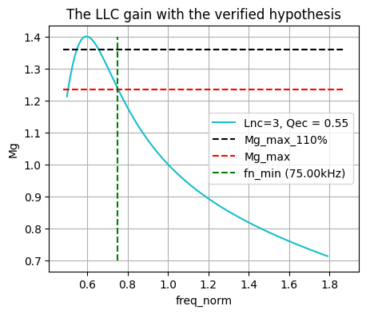

$ \begin{aligned} \mathrm{fmin}_{2} &= 75000.000 \; \\[10pt] \omega_{min} &= 471238.898 \; \\[10pt] \mathrm{Im}_{rms2} &= 2 \cdot \sqrt { 2 } \cdot n \cdot \frac{ \mathrm{Vo}_{nom} }{ \pi \cdot \mathrm{Lm} \cdot \omega_{min} } \\&= 2 \cdot \sqrt { 2 } \cdot 4.000 \cdot \frac{ 48.000 }{ 3.142 \cdot 0.000 \cdot 471238.898 } \\&= 5.610 \; \;\textrm{(Arms)}\\[10pt] \end{aligned} $

$ \begin{aligned} \mathrm{Im}_{peak2} &= \sqrt { 2 } \cdot \mathrm{Im}_{rms2} = \sqrt { 2 } \cdot 5.610 &= 7.933 \; \;\textrm{(A)} \\[10pt] I_{satMargin} &= 100 \cdot \frac{ \mathrm{Im}_{sat} - \mathrm{Im}_{peak2} }{ \mathrm{Im}_{sat} } = 100 \cdot \frac{ 9.524 - 7.933 }{ 9.524 } &= 16.704 \; \;\textrm{(\%)} \end{aligned} $

We can calculate also $B_{peak2}$ using $Im_{rms2}$

$ \begin{aligned} B_{sat} &= 300 \; \;\textrm{(mT)} \\[10pt] B_{peak2} &= 1 \times 10 ^ {3} \cdot \mathrm{Lm} \cdot \sqrt { 2 } \cdot \frac{ \mathrm{Im}_{rms2} }{ n \cdot A_{e_{min}} \cdot 1 \times 10 ^ {-6} } \\&= 1 \times 10 ^ {3} \cdot 0.000 \cdot \sqrt { 2 } \cdot \frac{ 5.610 }{ 4.000 \cdot 518 \cdot 1 \times 10 ^ {-6} } \\&= 250.369 \; \;\textrm{(mT < Bs= 300mT OK)}\\[10pt] \end{aligned} $

We calculate the margin for $B_{peak2}$

$ \begin{aligned} B_{satMargin} &= 100 \cdot \frac{ B_{sat} - B_{peak2} }{ B_{sat} } \\&= 100 \cdot \frac{ 300 - 250.369 }{ 300 } \\&= 16.544 \; \;\textrm{(\%)}\\[10pt] \end{aligned} $

The calculation $I_{m,\text{sat}} / I_{m,\text{peak}}$ and $B_{\text{peak}} / B_{\text{sat}}$ are equivalent, see the result below

$ \begin{aligned} I_{satMargin} &= 16.704 \; \;\textrm{(\%)} \\[10pt] B_{satMargin} &= 16.544 \; \;\textrm{(\%)} \end{aligned} $

### Other cores

Let’s apply the same formula to other cores, using the datasheet information shown below.

|  | core | Aemin(mm2) | Le(mm) | Ve(mm3) | Bsat mT | Loss (W/set) | K1 | K2 | µe | Al(nH) | price by set |
| --- | --- | --- | --- | --- | --- | --- | --- | --- | --- | --- | --- |
| 0 | E64/10/50-3C95 | 519.0 | 79.9 | 40700 | 330.0 | 20.0 | NaN | NaN | NaN | 17000 | 11.05 |
| 1 | ELP 43/10/28 with I 43/4/28 N87 | 217.0 | 50.8 | 11430 | 350.0 | 7.8 | 390.0 | -0.784 | 1480.0 | 850 | 2.61 |
| 2 | ELP 64/10/50 with I 64/5/50 N87 | 512.0 | 69.7 | 36200 | 300.0 | 4.8 | 835.0 | -0.790 | 1450.0 | 14000 | NaN |
| 3 | ELP 64/10/50 with ELP 64/10/50 N95 | 518.0 | 79.9 | 41500 | 320.0 | 5.1 | NaN | NaN | 1880.0 | 15500 | 14.52 |
| 4 | ELP 64/10/50 with ELP 64/10/50 N87 | 518.0 | 79.9 | 41500 | 300.0 | 5.5 | 820.0 | -0.767 | 1490.0 | 12500 | 11.27 |
| 5 | E64/10/50 + PLT64/50/5 3C95 | 519.0 | 69.7 | 35500 | 330.0 | 17.0 | NaN | NaN | NaN | 18500 | NaN |
| 6 | ER64/13/51-3C92 3C95 | 507.0 | 93.0 | 52600 | 330.0 | 25.0 | NaN | NaN | NaN | 17100 | 19.62 |
| 7 | E100/60/28 N87 | 690.0 | 274.0 | 201390 | 300.0 | 4.7 | NaN | NaN | 1930.0 | 6500 | 17.40 |
| 8 | ELP 102/20/38 with ELP 102/20/38 N87 | 524.5 | 147.6 | 79410 | 300.0 | 11.0 | NaN | NaN | 1790.0 | 8200 | 12.88 |
| 9 | ELP 102/20/38 with ELP 102/20/38 N97 | 524.5 | 147.6 | 79410 | 300.0 | 9.7 | NaN | NaN | 1855.0 | 8500 | 14.07 |
| 10 | ELP 102/20/38 with I 102/7/38 N97 | 534.2 | 121.2 | 67745 | 300.0 | 8.0 | NaN | NaN | 1740.0 | 9600 | NaN |
| 11 | E 80/38/20 N95 | 388.0 | 184.0 | 71800 | 330.0 | 8.0 | NaN | NaN | 1680.0 | 4500 | 4.33 |

The table below shows the calculated saturation current and air gap of each core.

|  | core | Im_sat | l_g |
| --- | --- | --- | --- |
| 0 | E64/10/50-3C95 | NaN | NaN |
| 1 | ELP 43/10/28 with I 43/4/28 N87 | 4.645828 | 0.032397 |
| 2 | ELP 64/10/50 with I 64/5/50 N87 | 9.395645 | 0.109357 |
| 3 | ELP 64/10/50 with ELP 64/10/50 N95 | 10.139467 | 0.116770 |
| 4 | ELP 64/10/50 with ELP 64/10/50 N87 | 9.505750 | 0.105646 |
| 5 | E64/10/50 + PLT64/50/5 3C95 | NaN | NaN |
| 6 | ER64/13/51-3C92 3C95 | NaN | NaN |
| 7 | E100/60/28 N87 | 12.662099 | 0.070187 |
| 8 | ELP 102/20/38 with ELP 102/20/38 N87 | 9.625031 | 0.078811 |
| 9 | ELP 102/20/38 with ELP 102/20/38 N97 | 9.625031 | 0.081700 |
| 10 | ELP 102/20/38 with I 102/7/38 N97 | 9.803034 | 0.094596 |
| 11 | E 80/38/20 N95 | 7.832151 | 0.009775 |

And the peak current is:

$ \begin{aligned} \mathrm{Im}_{peak2} &= 7.933 \; \;\textrm{(A)} \end{aligned} $

Below are the cores where the peak current is lower than the saturation current.

|  | core | Im_sat | l_g | I_sat_Margin % |
| --- | --- | --- | --- | --- |
| 2 | ELP 64/10/50 with I 64/5/50 N87 | 9.395645 | 0.109357 | 15.565680 |
| 4 | ELP 64/10/50 with ELP 64/10/50 N87 | 9.505750 | 0.105646 | 16.543684 |
| 9 | ELP 102/20/38 with ELP 102/20/38 N97 | 9.625031 | 0.081700 | 17.577938 |
| 8 | ELP 102/20/38 with ELP 102/20/38 N87 | 9.625031 | 0.078811 | 17.577938 |
| 10 | ELP 102/20/38 with I 102/7/38 N97 | 9.803034 | 0.094596 | 19.074557 |
| 3 | ELP 64/10/50 with ELP 64/10/50 N95 | 10.139467 | 0.116770 | 21.759704 |
| 7 | E100/60/28 N87 | 12.662099 | 0.070187 | 37.347287 |

`E100/60/28 N87` is not a planar core for pcb transformer.  
so the choice will be between : `ELP 64/10/50 with ELP 64/10/50 N95` and `ELP 102/20/38 with I 102/7/38 N97`

### Choice of the transformer core ELP 64 vs ELP 102

Below the 2D of cores ELP 64 and ELP 102

[figure not shown]

**Figure 3:** ELP 64/10/50 TDK core

[figure not shown]

**Figure 4:** ELP 102/20/38 TDK core

Below some dimensions of ELP 102 and ELP 64 and a figure show the PCB trace and the margin of a PCB layer

|  | core | E | F | Margin |
| --- | --- | --- | --- | --- |
| 0 | ELP 102 | 86.0 | 14.0 | 4 |
| 1 | ELP 64 | 53.6 | 10.2 | 4 |

[figure not shown]

**Figure 5:** ELP set, TDK, some mechanical dimensions

[figure not shown]

**Figure 6:** ELP PCB trace (one PCB layer)

See page 2 [4].

We will use the below formula to calculate the maximum alowed current for pcb trace

[figure not shown]

See page 50 [5].

In general, PCB copper is specified in ounces (oz). This can be converted to thickness using a simple formulas as below:

$ \begin{aligned} M_{density} &= 2 \; \;\textrm{(oz/ft2, PCB layer surface mass density)} \\[10pt] M_{density2} &= M_{density} \cdot 28.3495 = 2 \cdot 28.3495 &= 56.699 \; \;\textrm{(g/ft2 (1 oz = 28.3495g))} \\[10pt] M_{density3} &= \frac{ M_{density2} }{ \left( 30.48 \right) ^{ 2 } } = \frac{ 56.699 }{ \left( 30.48 \right) ^{ 2 } } &= 0.061 \; \;\textrm{(g/cm2 (1ft = 30,48 cm))} \\[10pt] \mathrm{Thickness}_{cm} &= \frac{ M_{density3} }{ 8.96 } = \frac{ 0.061 }{ 8.96 } &= 0.007 \; \;\textrm{(cm, copper density 8,96 g/cm³)} \\[10pt] \mathrm{Thickness}_{um} &= \mathrm{Thickness}_{cm} \cdot 1 \times 10 ^ {4} = 0.007 \cdot 1 \times 10 ^ {4} &= 68.114 \; \;\textrm{(µm)} \end{aligned} $

The following table summarizes all results for ELP 102 compared to ELP 64, for both outer and inner layers (Copper layer of 2 oz/ft²), and delta Temp = 30°C

|  | core | E | F | Margin | kind | wmm | Current |
| --- | --- | --- | --- | --- | --- | --- | --- |
| 0 | ELP 102 | 86.0 | 14.0 | 4 | outer | 28.0 | 71.787917 |
| 1 | ELP 102 | 86.0 | 14.0 | 4 | inner | 28.0 | 35.893959 |
| 2 | ELP 64 | 53.6 | 10.2 | 4 | outer | 13.7 | 42.754732 |
| 3 | ELP 64 | 53.6 | 10.2 | 4 | inner | 13.7 | 21.377366 |

The ELP 102 allows higher current due to its larger width, so we will choose this core. To minimize core losses, we will adopt N97 or N95 material.

Below is an example of an ELP/I 102 pair; the transformer cost will be around 24€.

[figure not shown]

[figure not shown]

**Figure 9:** Mouser, TDK, I 102/7/38 N97, B66297K0000X197

## Lr design

**The input data**

$ \begin{aligned} \mathrm{Lr}_{uH} &= 21.797 \; \;\textrm{(µH)} \\[10pt] \mathrm{Ir}_{rms} &= 10.354 \; \;\textrm{(Arms)} \end{aligned} $

**Relationship Between Inductance Ratio and Number of Turns**

|  | Nb | Al_nH |
| --- | --- | --- |
| 0 | 1.0 | 21797.000000 |
| 1 | 2.0 | 5449.250000 |
| 2 | 3.0 | 2421.888889 |
| 3 | 4.0 | 1362.312500 |
| 4 | 5.0 | 871.880000 |
| 5 | 6.0 | 605.472222 |
| 6 | 7.0 | 444.836735 |
| 7 | 8.0 | 340.578125 |
| 8 | 9.0 | 269.098765 |

### 4 turns, one turns by layer

#### alculation Using the ELP 58/11/38 Core

**Datasgeet information**

$ \begin{aligned} \mathrm{core} &= \mathrm{ELP 58/11/38}\ with \ I 58/4/38 N87 \; \\[10pt] \mathrm{Aemin} &= 308 \; \;\textrm{(mm2: datasheet)} \\[10pt] \mathrm{Al}_{nH0} &= 8400 \; \;\textrm{(nH: datasheet)} \\[10pt] \mathrm{Le} &= 67.700 \; \;\textrm{(mm: datasheet)} \\[10pt] \mathrm{K1} &= 591 \; \;\textrm{(datasheet)} \\[10pt] \mathrm{K2} &= -0.685 \; \;\textrm{(datasheet)} \\[10pt] B_{sat} &= 300 \; \;\textrm{(mT: datasheet)} \\[10pt] \mu_{e} &= 1540 \; \\[10pt] n &= 4 \; \;\textrm{(turns: 4 layers pcb)} \end{aligned} $

**$B_{peak}$ and the margin**

$ \begin{aligned} B_{peak} &= 1 \times 10 ^ {-3} \cdot \mathrm{Lr}_{uH} \cdot \sqrt { 2 } \cdot \frac{ \mathrm{Ir}_{rms} }{ n \cdot \mathrm{Aemin} \cdot 1 \times 10 ^ {-6} } \\&= 1 \times 10 ^ {-3} \cdot 21.797 \cdot \sqrt { 2 } \cdot \frac{ 10.354 }{ 4 \cdot 308 \cdot 1 \times 10 ^ {-6} } \\&= 259.065 \; \;\textrm{(mT)}\\[10pt] \\[10pt] B_{margin} &= 100 \cdot \frac{ B_{sat} - B_{peak} }{ B_{sat} } \\&= 100 \cdot \frac{ 300 - 259.065 }{ 300 } \\&= 13.645 \; \;\textrm{(\%)}\\[10pt] \end{aligned} $

**The Air Gap Calculated Using the TDK Factors K₁, K₂, and the Simple Formula**

TDK empirical formula using K1, K2

$ \begin{aligned} \mathrm{Al}_{nH} &= 1 \times 10 ^ {3} \cdot \frac{ \mathrm{Lr}_{uH} }{ \left( n \right) ^{ 2 } } = 1 \times 10 ^ {3} \cdot \frac{ 21.797 }{ \left( 4 \right) ^{ 2 } } &= 1362.312 \; \;\textrm{(nH/turn squared)} \end{aligned} $

$ \begin{aligned} s_{mm} &= \left( \frac{ \mathrm{Al}_{nH} }{ \mathrm{K1} } \right) ^{ \left( \frac{ 1 }{ \mathrm{K2} } \right) } = \left( \frac{ 1362.312 }{ 591 } \right) ^{ \left( \frac{ 1 }{ -0.685 } \right) } &= 0.295 \; \;\textrm{(mm airgap)} \end{aligned} $

Simple formula

$ \begin{aligned} \mathrm{lg}_{mm} &= \mathrm{Le} \cdot \frac{ \frac{ \mathrm{Al}_{nH0} }{ \mathrm{Al}_{nH} } - 1 }{ \mu_{e} } = 67.700 \cdot \frac{ \frac{ 8400 }{ 1362.312 } - 1 }{ 1540 } &= 0.227 \; \;\textrm{(mm)} \end{aligned} $

We use the TDK empirical formula

#### Gap error effect

One case calculation

$ \begin{aligned} s_{nom} &= 0.295 \; \;\textrm{(mm)} \\[10pt] \mathrm{error} &= 10 \; \;\textrm{(\%)} \\[10pt] s_{min} &= s_{nom} \cdot \left( 1 - \frac{ \mathrm{error} }{ 100 } \right) = 0.295 \cdot \left( 1 - \frac{ 10 }{ 100 } \right) &= 0.266 \\[10pt] s_{max} &= s_{nom} \cdot \left( 1 + \frac{ \mathrm{error} }{ 100 } \right) = 0.295 \cdot \left( 1 + \frac{ 10 }{ 100 } \right) &= 0.325 \\[10pt] \mathrm{Al}_{max} &= \left( s_{min} \right) ^{ \mathrm{K2} } \cdot \mathrm{K1} = \left( 0.266 \right) ^{ -0.685 } \cdot 591 &= 1464.268 \\[10pt] \mathrm{Al}_{min} &= \left( s_{max} \right) ^{ \mathrm{K2} } \cdot \mathrm{K1} = \left( 0.325 \right) ^{ -0.685 } \cdot 591 &= 1276.212 \\[10pt] \mathrm{Al}_{errorP} &= 100 \cdot \frac{ \mathrm{Al}_{max} - \mathrm{Al}_{nH} }{ \mathrm{Al}_{nH} } = 100 \cdot \frac{ 1464.268 - 1362.312 }{ 1362.312 } &= 7.484 \; \;\textrm{(\% of error of nH)} \\[10pt] \mathrm{Al}_{errorN} &= 100 \cdot \frac{ \mathrm{Al}_{min} - \mathrm{Al}_{nH} }{ \mathrm{Al}_{nH} } = 100 \cdot \frac{ 1276.212 - 1362.312 }{ 1362.312 } &= -6.320 \; \;\textrm{(\% of error of nH)} \end{aligned} $

Curve of air gap error impact for range [-50%, 50%]

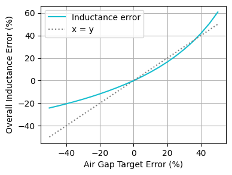

**The cores listed below are verified, but only the ‘ELP 58/11/38’ yields a B_peak below 300 mT.**

|  | core | Ae_min(mm2) | B_peak(mT) |
| --- | --- | --- | --- |
| 0 | ELP 22/6/16 with ELP 22/6/16 | 78.3 | 1019.056152 |
| 1 | ELP 32/6/20 with ELP 32/6/20 | 128 | 623.375732 |
| 2 | ELP 38/8/25 with ELP 38/8/25 | 192 | 415.583832 |
| 3 | ELP 43/10/28 with ELP 43/10/28 | 217 | 367.705536 |
| 4 | ELP 58/11/38 with ELP 58/11/38 | 308 | 259.065247 |

### More than 4 turns

Below the B_peak of rach core, with number of turns : (same formulas as above)

| core | ELP 22/6/16 with ELP 22/6/16 | ELP 32/6/20 with ELP 32/6/20 | ELP 38/8/25 with ELP 38/8/25 | ELP 43/10/28 with ELP 43/10/28 | ELP 58/11/38 with ELP 58/11/38 |
| --- | --- | --- | --- | --- | --- |
| Ae_min(mm2) | 78.3 | 128 | 192 | 217 | 308 |
| B_peak n=1 | 4076.224609 | 2493.50293 | 1662.335327 | 1470.822144 | 1036.260986 |
| B_peak n=2 | 2038.112305 | 1246.751465 | 831.167664 | 735.411072 | 518.130493 |
| B_peak n=3 | 1358.741455 | 831.167664 | 554.111755 | 490.274017 | 345.420349 |
| B_peak n=4 | 1019.056152 | 623.375732 | 415.583832 | 367.705536 | 259.065247 |
| B_peak n=5 | 815.244873 | 498.700623 | 332.467072 | 294.164429 | 207.252197 |
| B_peak n=6 | 679.370728 | 415.583832 | 277.055878 | 245.137009 | 172.710175 |
| B_peak n=7 | 582.317749 | 356.214722 | 237.476486 | 210.117432 | 148.037292 |
| B_peak n=8 | 509.528076 | 311.687866 | 207.791916 | 183.852768 | 129.532623 |

The cases with B_peak < B_sat

| core n | ELP 38/8/25 with ELP 38/8/25 | ELP 43/10/28 with ELP 43/10/28 | ELP 58/11/38 with ELP 58/11/38 |
| --- | --- | --- | --- |
| 4 | NaN | NaN | 259.065247 |
| 5 | NaN | 294.164429 | 207.252197 |
| 6 | 277.055878 | 245.137009 | 172.710175 |
| 7 | 237.476486 | 210.117432 | 148.037292 |
| 8 | 207.791916 | 183.852768 | 129.532623 |

Remind the relationship Between Inductance Ratio and Number of Turns

|  | 0 | 1 | 2 | 3 | 4 | 5 | 6 | 7 | 8 |
| --- | --- | --- | --- | --- | --- | --- | --- | --- | --- |
| Nb | 1.0 | 2.0 | 3.0 | 4.0 | 5.0 | 6.0 | 7.0 | 8.0 | 9.0 |
| Al_nH | 21797.0 | 5449.0 | 2422.0 | 1362.0 | 872.0 | 605.0 | 445.0 | 341.0 | 269.0 |

[figure not shown]

**Figure 10:** TDK, ELP43/10/28 datasheet screenshot

Below a core set thant meet aour calculation in mouser:

[figure not shown]

**Figure 11:** Mouser, TDK, ELP43/10/28 N87 gap 1.0+-0.05 mm, B66291G1000X187

**Max current of each layer**

[figure not shown]

**Figure 12:** PCB copper trace proposition: 2 turns by layer

We will use the same formula as in the section `Choice of the transformer core ELP 64 vs ELP 102`. Using this, we can determine the current for the inner and outer layers.  
From the datasheet:

|  | core | E | F | Margin |
| --- | --- | --- | --- | --- |
| 0 | ELP 43 | 35.4 | 8.1 | 3 |

The following table summarizes all results for ELP 43, for both outer and inner layers (Copper layer of 2 oz/ft²), and delta Temp = 30°C

|  | core | E | F | Margin | kind | wmm | Current |
| --- | --- | --- | --- | --- | --- | --- | --- |
| 0 | ELP 43 | 35.4 | 8.1 | 3 | outer | 7.65 | 28.023109 |
| 1 | ELP 43 | 35.4 | 8.1 | 3 | inner | 7.65 | 14.011555 |

Reminde the RMS max current of the `Lr`

$ \begin{aligned} \mathrm{Ir}_{rms} &= 10.354 \; \;\textrm{(Arms < Imax inner layer)} \end{aligned} $

## Bill of Materials (BOM) of this transformer and Lr (Cores)

|  | Mouser No | Mfr. No | Number | componenent | remark |
| --- | --- | --- | --- | --- | --- |
| 0 | 871-B66291G1000X187 | B66291G1000X187 | 2 | LLC resonant inductor | ELP43/10/28 N87 gap 1.0+-0.05 mm |
| 1 | 871-B66297GX197 | B66297G0000X197 | 1 | LLC Transformer | ELP102/20.3/37.5 N97 8500 + 25- 25% |
| 2 | 871-B66297KX197 | B66297K0000X197 | 1 | LLC Transformer | I102/7/37.5 N97 9600 + 25- 25% |

## References

[1] [TDK, Ferrites and accessories, E cores General information](https://www.tdk-electronics.tdk.com/download/531516/f119bbe0ab3d6dd73ae31c6fa9dcf6b9/pdf-ecoresgeneralinformation.pdf)  
[2] [TDK, Ferrites and accessories, Processing notes](https://www.tdk-electronics.tdk.com/download/531538/d5537837a7b4f3cd2fc2e7da8e093820/pdf-processingnotes.pdf)  
[3] [TDK, EPCOS Data Book 2013](https://www.tdk-electronics.tdk.com/download/519704/069c210d0363d7b4682d9ff22c2ba503/ferrites-and-accessories-db-130501.pdf)  
[4] [TDK, Planar Cores for Power Applications](https://www.tdk-electronics.tdk.com/download/2527778/1e429cb7ad3fd0be062bcfe03f8ed498/ferrites-planar-cores-pb.pdf)  
[5] [IPC-2221A, Generic Standard on Printed Board Design](https://www-eng.lbl.gov/~shuman/NEXT/CURRENT_DESIGN/TP/MATERIALS/IPC-2221A%28L%29.pdf)

**Datasheets of the transformer core candidates**  
https://www.ferroxcube.com/upload/media/product/file/Pr_ds/E64_10_50.pdf  
https://www.tdk-electronics.tdk.com/inf/80/db/fer/elp_43_10_28.pdf  
https://product.tdk.com/system/files/dam/doc/product/ferrite/ferrite/ferrite-core/data_sheet/80/db/fer/elp_64_10_50.pdf  
https://www.ferroxcube.com/upload/media/product/file/Pr_ds/E64_10_50_PLT64_50_5.pdf  
https://www.ferroxcube.com/upload/media/product/file/Pr_ds/ER64_13_51.pdf  
https://product.tdk.com/system/files/dam/doc/product/ferrite/ferrite/ferrite-core/data_sheet/80/db/fer/e_100_60_28.pdf  
https://product.tdk.com/system/files/dam/doc/product/ferrite/ferrite/ferrite-core/data_sheet/80/db/fer/elp_102_20_38.pdf  
https://www.tdk-electronics.tdk.com/inf/80/db/fer/e_80_38_20.pdf

**Datasheets of the resonant inductor core candidates**  
https://www.tdk-electronics.tdk.com/inf/80/db/fer/elp_22_6_16.pdf  
https://www.tdk-electronics.tdk.com/inf/80/db/fer/elp_32_6_20.pdf  
https://www.tdk-electronics.tdk.com/inf/80/db/fer/elp_38_8_25.pdf  
https://www.tdk-electronics.tdk.com/inf/80/db/fer/elp_43_10_28.pdf  
https://www.tdk-electronics.tdk.com/inf/80/db/fer/elp_58_11_38.pdf